# Data Visualisation

P.V.S.N.Madushani

9/3/2020

## **1. Exploratory Data Analysis**

Part 1 of this article provides an exploratory data analysis for the dataset “DataScientistQualificationSkills”.

##### **1.1 Analysis of Job Titles**

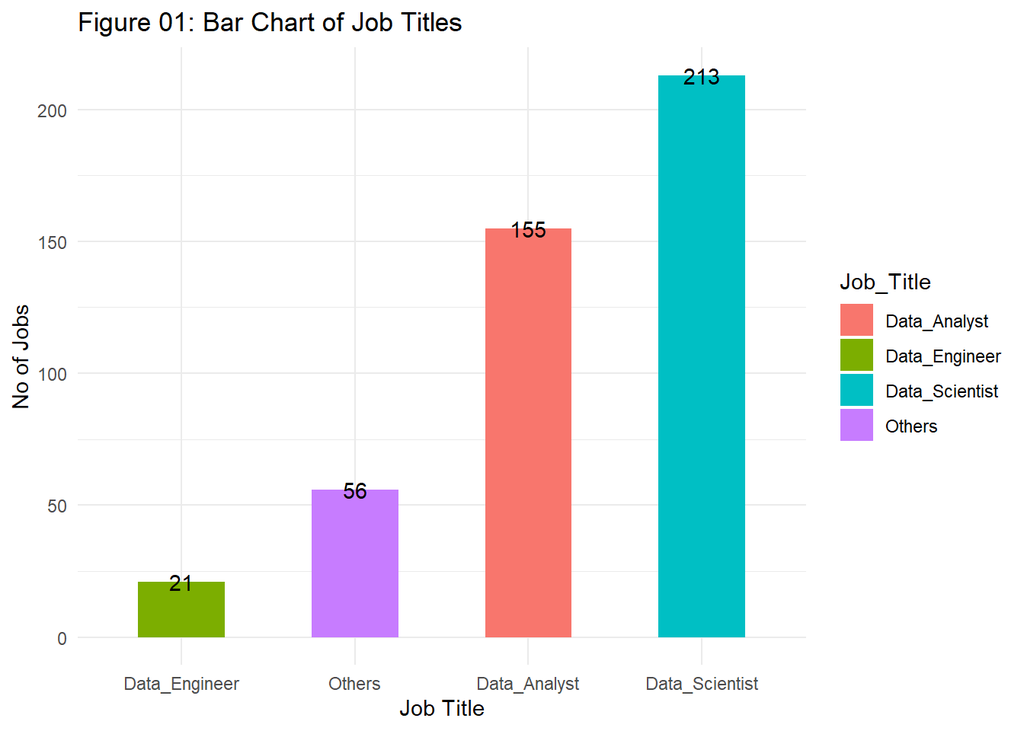

##### **1.2Analysis of Software**

```
## # A tibble: 36 x 2
##    RequiredSoftwares no_rows
##    <chr>               <int>
##  1 Python                281
##  2 SQL                   238
##  3 R                     209
##  4 Ms Excel               83
##  5 SAS                    80
##  6 Tableau                73
##  7 cloud_storage          65
##  8 Java                   42
##  9 Hadoop                 41
## 10 MySQL                  41
## # ... with 26 more rows
```

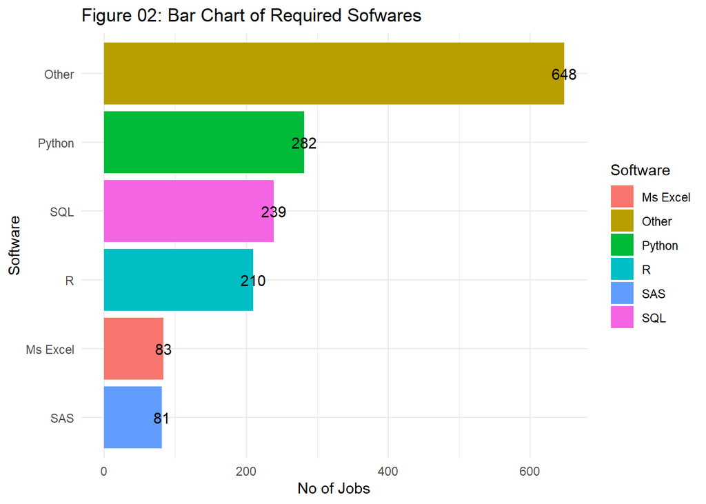

Figure 02 shows the highly required software for statistical jobs. Most required software are Python,SQL and R. Also there are 648 jobs which required other software which do not specify here.

**Figure 03: Word Cloud for Other Option**

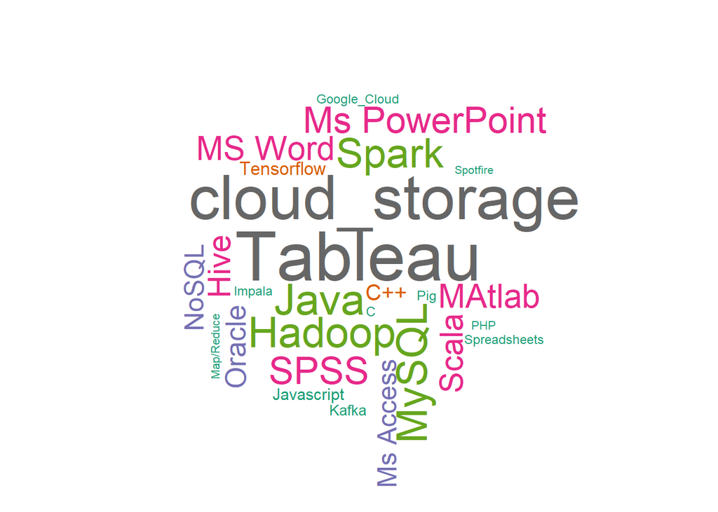

Above Word Cloud shows the software under other option of figure 02.By seeing this figure we can say that **Tableau** and **Cloud Storage** are the most required software in the other option of figure 02.

##### **1.3 Analysis of Countries**

```
## # A tibble: 30 x 2
##    Location  no_rows
##    <chr>       <int>
##  1 USA            91
##  2 India          85
##  3 Sri Lanka      64
##  4 Singapore      32
##  5 Australia      31
##  6 UK             26
##  7 Canada         22
##  8 China          20
##  9 Malaysia       12
## 10 Japan           6
## # ... with 20 more rows
```

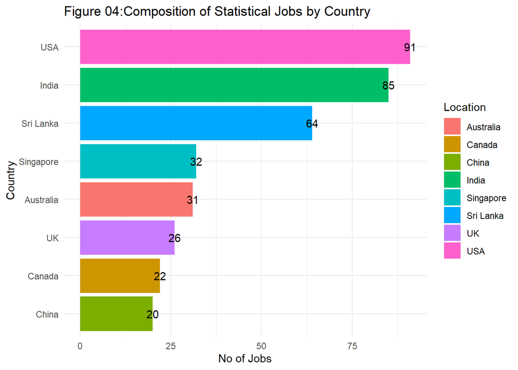

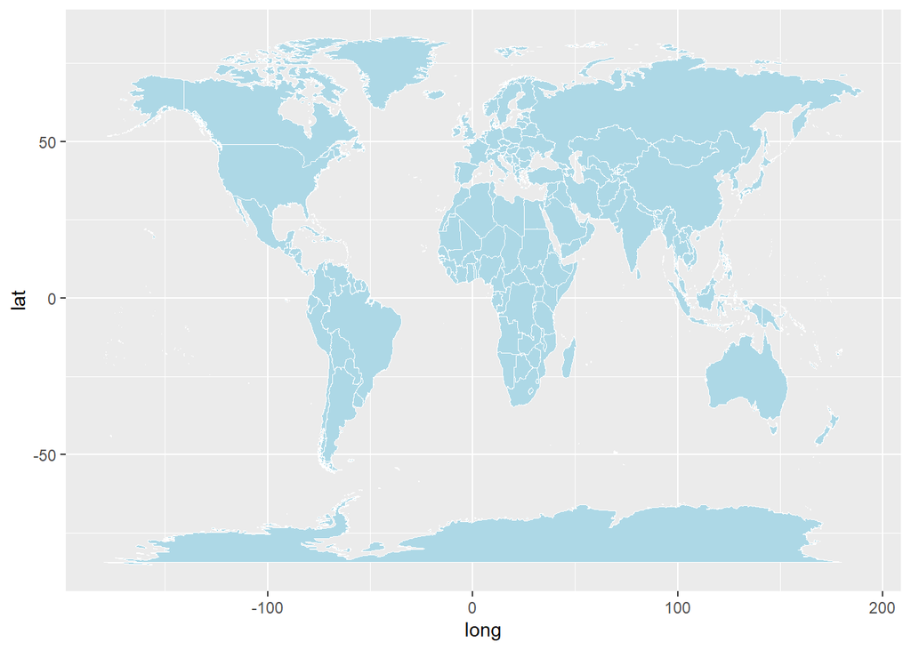

## **2. Flex Dashboard Design**

##### **Panel 1: Overview**

**Developers :** Names of stat-special batch 2015/16 of USJ

**Composition of jobs by countries :** Figure 04

##### **Panel 2: World Map**

##### **Panel 3: Software Analysis**

Figure 02, Figure 03

##### **Panel 4: Analysis of jobs**

Figure 01

Figure 01 shows the main three jobs in the dataset. We can develop the dashboard as when we click on a bar it shows the word cloud of knowledge in of that job.

##### **Panel 5: Distributions**

1. Boxplots of salary by job title
2. Boxplot of salary by Education Qualification